# Application on GDSC dataset

This file outlines the key steps of sTPLS when applying to the paired gene expresssion and drug response data from the GDSC dataset.

### Load input data

The input tensor was generated by “./R/generate_GDSC_data.R”

```r
data.type = "GDSC_data" # all related results are saved in "./examples/data.type/"
data.tensor = readRDS("./data/GDSC_data_tensor.RDS")
```

### Select parameters

Given candidates for parameters (alpha_cu, alpha_cv, beta), sTPLS algorithm using each group of parameters is executed to identify comodules. The median of modularity scores for all comodules is used to evaluate the performance when using different parameters. The optimal parameters corresponding to the largest score are selected. Considering the influence of comodules size on scores, we computed the median of modularity scores for comodules when selecting different numbers of three types of members in comodules by setting uthrd, vthrd and wthrd.

Firstly set candidates for parameters (alpha_cu, alpha_cv, beta).

```r
nfactor = 10 # the number of identified comodules
beta_list = seq(from = 1.5, to = 2.5, by = 0.5) # beta for weight w
alpha_cu_list = c(0.1, 0.2, 0.3)  # alpha for c_u
alpha_cv_list = c(0.1, 0.2, 0.3)  # alpha for c_v

combparams = expand.grid(beta_list, alpha_cu_list, alpha_cv_list, nfactor)
colnames(combparams) = c("beta","alpha_cu","alpha_cv","nfactor")
```

Then set candidates for the number of selected members in comodules. They could be set according to the user’s expectations for comodules size and understanding of the input data.

```r
uthrd_list = c(5,10,15) # the number of selected drugs
vthrd_list = c(100,150,200) # the number of selected genes
wthrd_list = 1:3 # the number of selected cancer types
uvwthrds = expand.grid(uthrd_list, vthrd_list, wthrd_list)
colnames(uvwthrds) = c("uthrd", "vthrd", "wthrd")
```

Lastly select the optimal parameters (alpha_cu, alpha_cv, beta) in sTPLS.

```r
source("./R/select_params.R")
opt_params = select_params(data_tensor=data.tensor, parameter_list=combparams, uvwthrd_list=uvwthrds, data_type=data.type)
```

```
## [1] "using parameters: alpha_cu=0.1, alpha_cv=0.1, beta=1.5, nfactor=10"
## [1] "using parameters: alpha_cu=0.1, alpha_cv=0.1, beta=2, nfactor=10"
## [1] "using parameters: alpha_cu=0.1, alpha_cv=0.1, beta=2.5, nfactor=10"
## [1] "using parameters: alpha_cu=0.2, alpha_cv=0.1, beta=1.5, nfactor=10"
## [1] "using parameters: alpha_cu=0.2, alpha_cv=0.1, beta=2, nfactor=10"
## [1] "using parameters: alpha_cu=0.2, alpha_cv=0.1, beta=2.5, nfactor=10"
## [1] "using parameters: alpha_cu=0.3, alpha_cv=0.1, beta=1.5, nfactor=10"
## [1] "using parameters: alpha_cu=0.3, alpha_cv=0.1, beta=2, nfactor=10"
## [1] "using parameters: alpha_cu=0.3, alpha_cv=0.1, beta=2.5, nfactor=10"
## [1] "using parameters: alpha_cu=0.1, alpha_cv=0.2, beta=1.5, nfactor=10"
## [1] "using parameters: alpha_cu=0.1, alpha_cv=0.2, beta=2, nfactor=10"
## [1] "using parameters: alpha_cu=0.1, alpha_cv=0.2, beta=2.5, nfactor=10"
## [1] "using parameters: alpha_cu=0.2, alpha_cv=0.2, beta=1.5, nfactor=10"
## [1] "using parameters: alpha_cu=0.2, alpha_cv=0.2, beta=2, nfactor=10"
## [1] "using parameters: alpha_cu=0.2, alpha_cv=0.2, beta=2.5, nfactor=10"
## [1] "using parameters: alpha_cu=0.3, alpha_cv=0.2, beta=1.5, nfactor=10"
## [1] "using parameters: alpha_cu=0.3, alpha_cv=0.2, beta=2, nfactor=10"
## [1] "using parameters: alpha_cu=0.3, alpha_cv=0.2, beta=2.5, nfactor=10"
## [1] "using parameters: alpha_cu=0.1, alpha_cv=0.3, beta=1.5, nfactor=10"
## [1] "using parameters: alpha_cu=0.1, alpha_cv=0.3, beta=2, nfactor=10"
## [1] "using parameters: alpha_cu=0.1, alpha_cv=0.3, beta=2.5, nfactor=10"
## [1] "using parameters: alpha_cu=0.2, alpha_cv=0.3, beta=1.5, nfactor=10"
## [1] "using parameters: alpha_cu=0.2, alpha_cv=0.3, beta=2, nfactor=10"
## [1] "using parameters: alpha_cu=0.2, alpha_cv=0.3, beta=2.5, nfactor=10"
## [1] "using parameters: alpha_cu=0.3, alpha_cv=0.3, beta=1.5, nfactor=10"
## [1] "using parameters: alpha_cu=0.3, alpha_cv=0.3, beta=2, nfactor=10"
## [1] "using parameters: alpha_cu=0.3, alpha_cv=0.3, beta=2.5, nfactor=10"
## [1] "All results have been saved in ./examples/GDSC_data/select_params/"
## [1] "Select the optimal parameters: alpha_cu=0.1, alpha_cv=0.1, beta=2, nfactor =10"
```

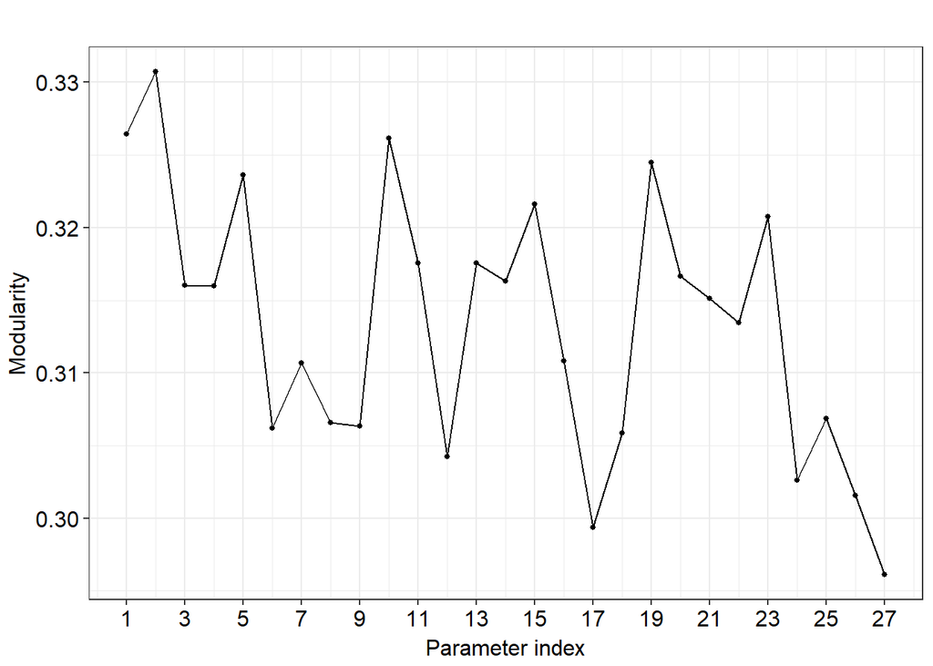

Set the parameters in sTPLS.

```r
beta = opt_params$beta # beta for weight w
alpha_cu = opt_params$alpha_cu # alpha for c_u
alpha_cv = opt_params$alpha_cv # alpha for c_v
nfactor = opt_params$nfactor # the number of identified comodules
```

### Run sTPLS algorithm

Run sTPLS using the selected parameters and save the results in the directory “./examples/GDSC_data”.

```r
source("./R/utils_for_sTPLS.R")
out.sTPLS = run_sTPLS(data_tensor=data.tensor, alpha_cu=alpha_cu, alpha_cv=alpha_cv, beta=beta, nfactor=nfactor, data_type=data.type)
```

```
## The results had been saved in ./examples/GDSC_data/alpha0.1_0.1_beta2_nfactor10.
## Load the results when alpha_cu=0.1, alpha_cv=0.1, beta=2, nfactor=10.
```

### Visualize sTPLS results

Draw heatmaps of weight matrices U,V,W.

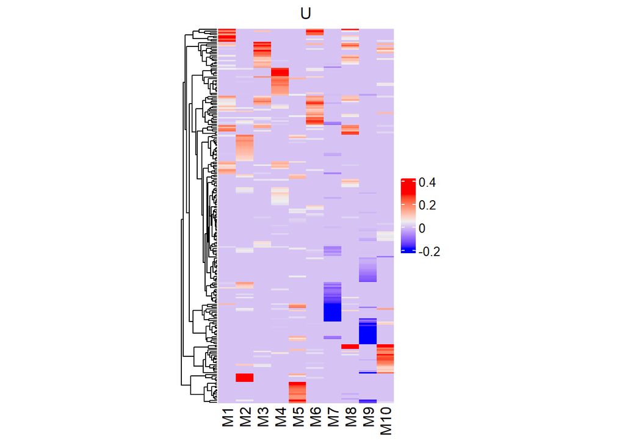

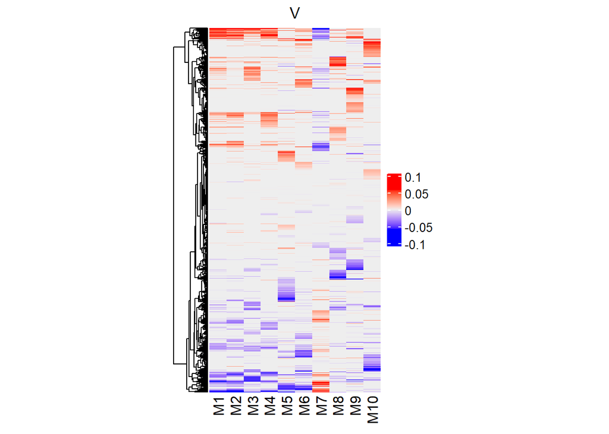

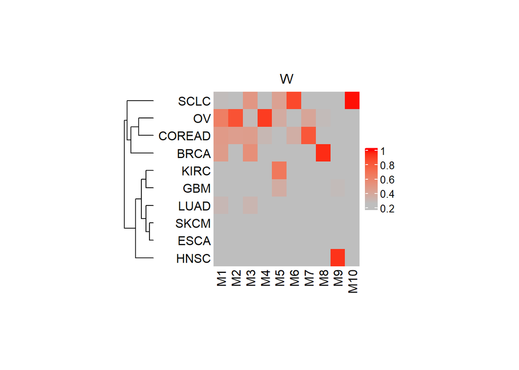

```r
# weight matrices of sTPLS
U=out.sTPLS$U; V=out.sTPLS$V; W=out.sTPLS$W
plot_UVW(U,V,W)
```

### Determine comodule members

Comodule members are determined based on weight matrices U,V and W. Thresholds (uthrd, vthrd, wthrd) should be set for selecting comodule members (i.e., features corresponding to three dimensions of input tensor). Adjust them for selecting comodules in proper size users prefer to. The larger the thresholds are, the less members are selected.

```r
uthrd = 3.5; vthrd = 3.5; wthrd = 1 # thresholds for selection comodule members
weight_list = list(U=U,V=V,W=W)
uvwthrd_list = list(uthrd=uthrd, vthrd=vthrd, wthrd=wthrd)
comodules = determine_comodule(weight_list, uvwthrd_list)
```

```
## [1] "Using uvwthrd = 3.5 and 3.5 and 1 to select comodule members."
## Numbers of selected comodule members:
##  for Dim1 - 6, 5, 7, 6, 6, 9, 8, 7, 9, 7;
##  for Dim2 - 174, 186, 176, 184, 182, 187, 192, 188, 189, 189;
##  for Dim3 - 3, 1, 3, 1, 1, 1, 1, 1, 1, 1 .
```

List the comodule members.

```r
print(head(comodules[[8]]$Dim1))
```

```
##   Dim1_index        Name    Weight
## 1        173 Refametinib 0.3747954
## 2        249  Trametinib 0.3418890
## 3        208 Selumetinib 0.3278948
## 4        255     AZD5438 0.2838904
## 5        282    RAF_9304 0.2597920
## 6        265       BPTES 0.2515360
```

```r
print(head(comodules[[8]]$Dim2))
```

```
##   Dim2_index   Name     Weight
## 1       3370   CISH 0.09616107
## 2       3394 ZBTB42 0.08225631
## 3       5674 IGFBP2 0.08150527
## 4       3458  PDCD4 0.07832950
## 5       3386   EPN3 0.07802035
## 6        575  SYNE4 0.07735440
```

```r
print(head(comodules[[8]]$Dim3))
```

```
##   Dim3_index Name   Weight
## 1          3 BRCA 0.947666
```

Save comodules and write the comodules in an excel file.

```r
resfolder = paste0("./examples/", data.type, "/")
save(comodules, file = paste0(resfolder, "comodules.RData"))

comodule_to_excel(comodules, destdir=resfolder)
```

### Visualize comodules

Demonstrate the comodules’ composition. Each row represents one comodule, and each column represents one feature. If feature j is included in the comodule Mi, the corresponding position (i, j) is filled in black color.

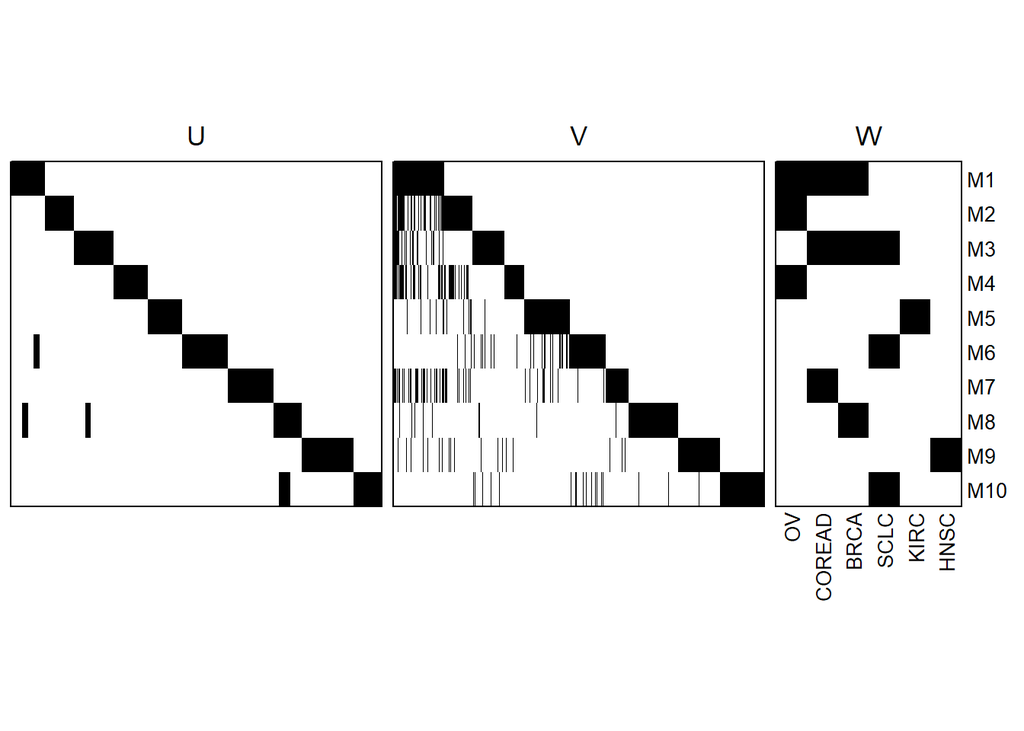

```r
source("./R/comodule_heatmap.R")
plot_comodule_member(tensor=data.tensor, comodules=comodules)
```

Draw heatmaps of comodules, unfold tensor along the condition dimension.

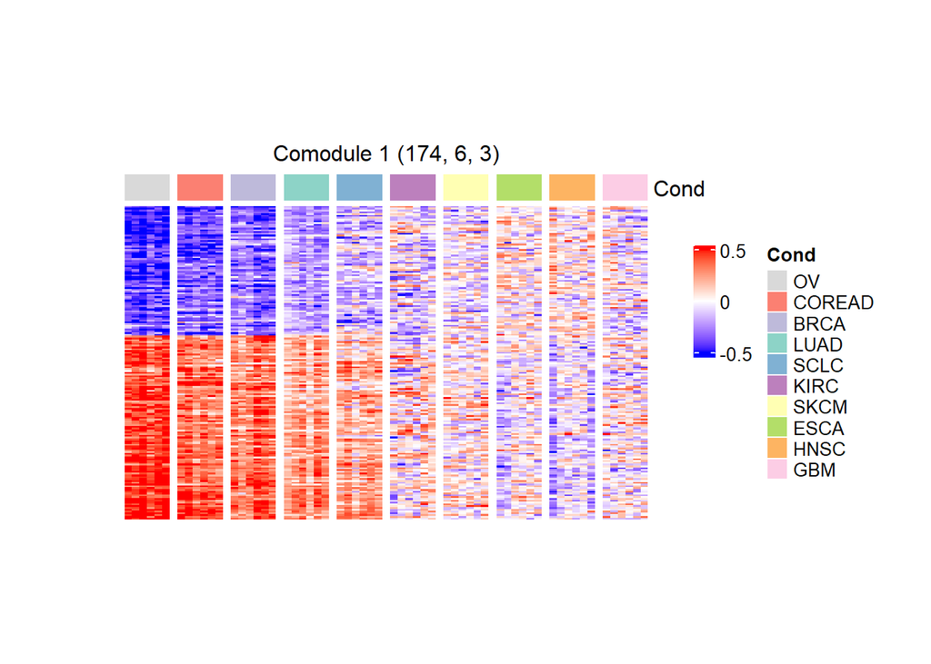

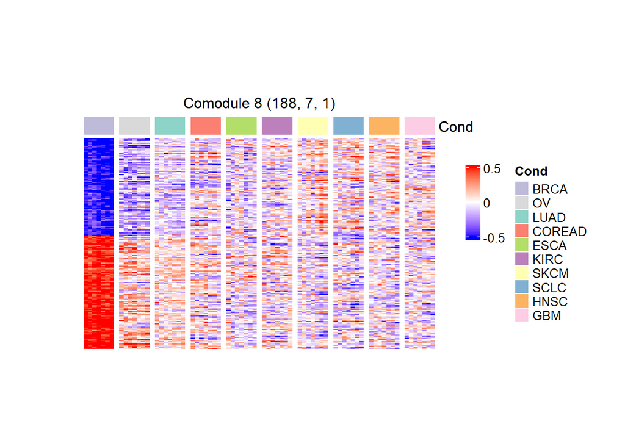

```r
# Draw heatmaps of comodule 1 and 8.
plot_comodule_heatmap(tensor=data.tensor, weight_list=weight_list, comodules=comodules, mindex=c(1,8))
```